# IC11-2-Case 31 - Summary of Data Analysis: R1, R2, R5, & R6

Willy Su

2026-11-24

## Data Preparation

```
[1] 128  53
```

```
 [1] "q3"           "q4"           "q5"           "q6"           "q7"
 [6] "q8"           "q9"           "q10"          "q11"          "q12"
[11] "q13"          "q14"          "q15"          "q16"          "q17"
[16] "q18"          "q19"          "q20"          "q21"          "q22"
[21] "q23"          "q24"          "q25"          "q26"          "q27"
[26] "q30"          "q31"          "q32"          "q33"          "q34"
[31] "q37"          "q38"          "Att_employee" "filter_$"     "Q7_r"
[36] "Q8_r"         "Q37_r"        "q9_r"         "q10_r"        "q13_r"
[41] "q14_r"        "q15_r"        "q16_r"        "q17_r"        "q18_r"
[46] "q19_r"        "q20_r"        "q21_r"        "q22_r"        "q23_r"
[51] "q24_r"        "q25_r"        "q26_r"
```

## R1: Reasons for Joining the Credit Union

### Descriptive Statistics

Table 1: Distribution of Members’ Opinions on Savings Interest Rates

```
 Very High       High    Average        Low   Very Low No Opinion
         1          2          3          4          5          6
```

```
   2    3    4    5 <NA>
  22   83   12    1   10
```

```
    2     3     4     5
18.64 70.34 10.17  0.85
```

## R1: One-Sample t-test

```
[1] 2.932203
```

```
[1] 0.5658186
```

```
    One Sample t-test

data:  q7_valid
t = -1.3016, df = 117, p-value = 0.1956
alternative hypothesis: true mean is not equal to 3
95 percent confidence interval:
 2.829046 3.035361
sample estimates:
mean of x
 2.932203
```

## R1: Savings Interest Rate Perceptions

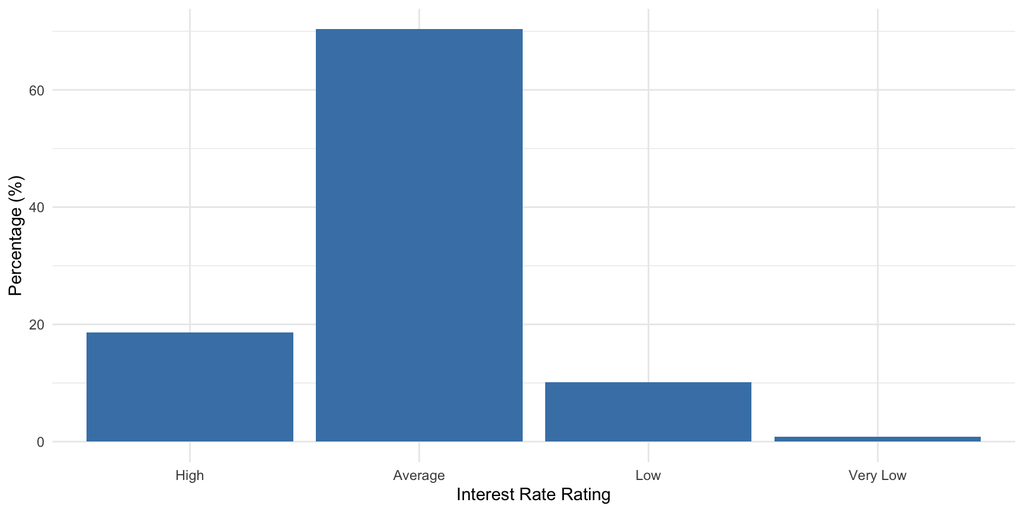

Figure 1: Members’ Perceptions of Savings Interest Rates

## R1: Findings and Insights

As shown in Figure 1, most members (70.34%) perceived the credit union’s savings interest rates as average, while 18.64% rated them as high and 11.02% rated them as low or very low.

The average rating was not significantly different from the midpoint of 3 (M = 2.93, SD = 0.57, t(117) = -1.30, p = .196).

These findings suggest that savings interest rates may not be a strong competitive advantage for attracting new members. However, Q7 measures rate perceptions rather than actual reasons for joining.

## R2: Reasons for Borrowing from Other Financial Institutions

### Descriptive Statistics

```
 Very Low       Low   Average      High Very High
        1         2         3         4         5
```

```
   1    2    3    4    5 <NA>
   1   17   59   26    4   21
```

```
    1     2     3     4     5
 0.93 15.89 55.14 24.30  3.74
```

## R2: Descriptive Statistics — Competitors

```
Strongly Disagree          Disagree         Uncertain             Agree
                1                 2                 3                 4
   Strongly Agree
                5
```

```
 1  2  3  4  5
 4 27 59 33  5
```

```
    1     2     3     4     5
 3.12 21.09 46.09 25.78  3.91
```

## R2: One-Sample t-test — Loan Rates

```
[1] 3.140187
```

```
[1] 0.757959
```

```
    One Sample t-test

data:  q8_valid
t = 1.9132, df = 106, p-value = 0.05842
alternative hypothesis: true mean is not equal to 3
95 percent confidence interval:
 2.994913 3.285461
sample estimates:
mean of x
 3.140187
```

## R2: One-Sample t-test — Competitors

```
[1] 3.0625
```

```
[1] 0.8671612
```

```
    One Sample t-test

data:  q30_valid
t = 0.81543, df = 127, p-value = 0.4164
alternative hypothesis: true mean is not equal to 3
95 percent confidence interval:
 2.91083 3.21417
sample estimates:
mean of x
   3.0625
```

## R2: Loan Rate Perceptions

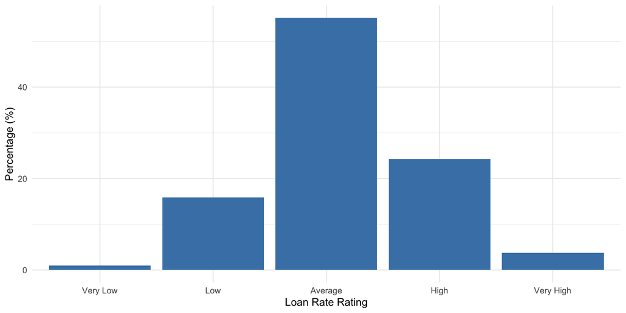

Figure 2: Members’ Perceptions of Credit Union Loan Rates

## R2: Loan Rates Compared to Competitors

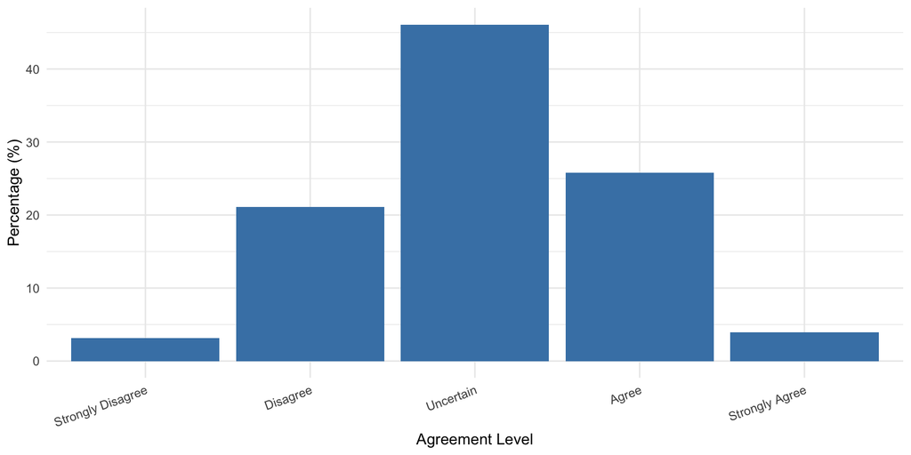

Figure 3: Agreement That Credit Union Loan Rates Are Lower

## R2: Findings and Insights

As shown in Figure 2, 55.14% of members perceived the credit union’s loan rates as average, while 28.04% rated them as high or very high.

As shown in Figure 3, 46.09% of members were uncertain whether the credit union offered lower loan rates than its competitors.

Neither loan rate perceptions (M = 3.14, t(106) = 1.91, p = .058) nor agreement about lower loan rates (M = 3.06, t(127) = 0.82, p = .416) differed significantly from the midpoint.

## R2: Recommendations

These findings suggest that the credit union could improve communication about its loan rates and competitive advantages. However, the results do not directly establish why members borrow from other financial institutions.

## R5: Awareness of Credit Union Services

### Descriptive Statistics

```
$q13_r
x
 1  2  3
83 32 13

$q14_r
x
 1  2  3
46 70 12

$q15_r
x
 1  2  3
42 75 11

$q16_r
x
 1  2  3
35 64 29

$q17_r
x
 1  2  3
15 57 56

$q18_r
x
  1   2   3
  5 104  19

$q19_r
x
 1  2  3
 5 99 24
```

## R5: Descriptive Statistics — Q20–Q26

```
$q20_r
x
  1   2   3
 12 102  14

$q21_r
x
 1  2  3
33 83 12

$q22_r
x
 1  2  3
37 80 11

$q23_r
x
 1  2  3
55 60 13

$q24_r
x
 1  2  3
69 57  2

$q25_r
x
 1  2  3
78 46  4

$q26_r
x
 2  3
80 48
```

## R5: Recoding Verification

```
[1] "Q13-Aware_regular share account"
```

```
    Aware and Have Used Aware but Have Not Used      Unaware of Service
                      1                       2                       3
```

```
        Recoded
Original  1  2  3
       1  0  0 13
       2  0 32  0
       3 83  0  0
```

## R5: Summary of Service Awareness

Table 2: Response Distribution Across Credit Union Services

| Question | Unaware | Aware_Not_Used | Aware_Used | Total |
| --- | --- | --- | --- | --- |
| q13_r | 83 | 32 | 13 | 128 |
| q14_r | 46 | 70 | 12 | 128 |
| q15_r | 42 | 75 | 11 | 128 |
| q16_r | 35 | 64 | 29 | 128 |
| q17_r | 15 | 57 | 56 | 128 |
| q18_r | 5 | 104 | 19 | 128 |
| q19_r | 5 | 99 | 24 | 128 |
| q20_r | 12 | 102 | 14 | 128 |
| q21_r | 33 | 83 | 12 | 128 |
| q22_r | 37 | 80 | 11 | 128 |
| q23_r | 55 | 60 | 13 | 128 |
| q24_r | 69 | 57 | 2 | 128 |
| q25_r | 78 | 46 | 4 | 128 |
| q26_r | 0 | 80 | 48 | 128 |

## R5: Chi-Square Goodness-of-Fit Test

Table 3: Chi-Square Test Results for Service Awareness

| Question | Chi_Square | df | P_Value | Significant |
| --- | --- | --- | --- | --- |
| q13_r | 61.42 | 2 | <0.001 | Yes |
| q14_r | 39.81 | 2 | <0.001 | Yes |
| q15_r | 48.02 | 2 | <0.001 | Yes |
| q16_r | 16.42 | 2 | <0.001 | Yes |
| q17_r | 26.92 | 2 | <0.001 | Yes |
| q18_r | 134.55 | 2 | <0.001 | Yes |
| q19_r | 115.80 | 2 | <0.001 | Yes |
| q20_r | 123.81 | 2 | <0.001 | Yes |
| q21_r | 62.36 | 2 | <0.001 | Yes |
| q22_r | 56.92 | 2 | <0.001 | Yes |
| q23_r | 31.23 | 2 | <0.001 | Yes |
| q24_r | 59.83 | 2 | <0.001 | Yes |
| q25_r | 64.56 | 2 | <0.001 | Yes |
| q26_r | 76.00 | 2 | <0.001 | Yes |

## R5: Service Awareness and Usage

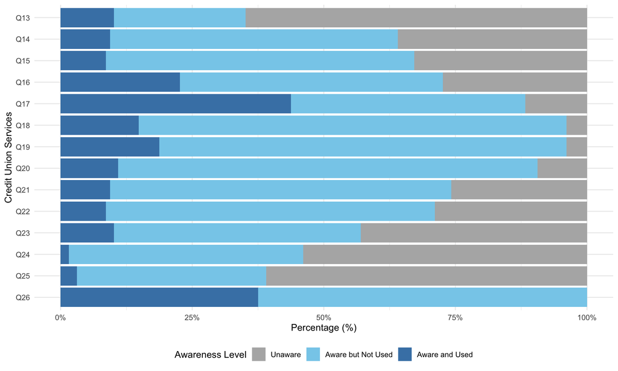

Figure 4: Awareness and Usage of Credit Union Services

## R5: Findings and Insights

As shown in Figure 4, awareness and usage patterns vary across the 14 credit union services.

All 14 chi-square goodness-of-fit tests were statistically significant (p < .001), indicating that the response distributions differed significantly from an equal distribution.

For Q13, 64.84% of respondents were unaware of the service. In contrast, all respondents were aware of the service represented by Q26, although only 37.50% had used it.

## R5: Recommendations

The findings suggest that the credit union should increase awareness of less familiar services and encourage members to use services they already know about.

## R6: Operational Effectiveness

### Descriptive Statistics

```
$q9_r
x
 2  3
29 99

$q10_r
x
 1  2  3  4
 2  4 54 68

$q11
x
  1   2
125   3

$q12
x
 1  2  3
74 32 22
```

## R6: Descriptive Statistics — Ratings

```
$q31
x
 1  3  4  5
 1 27 77 23

$q32
x
 2  3  4  5
 6 45 56 21

$q33
x
 2  3  4  5
 7 45 69  7

$q34
x
 1  2  3  4  5
 2 14 38 71  3

$Q37_r
x
   1    2    3    4    5 <NA>
   1    2   16   71   31    7
```

## R6: Data Recoding

Table 4: Valid Responses for Q11 and Q12

```
  1   2
  3 125
```

```
   1    2 <NA>
  32   74   22
```

## R6: Chi-Square Goodness-of-Fit Test

Table 5: Chi-Square Tests for Operational Effectiveness

| Question | N | Chi_Square | df | P_Value | Significant |
| --- | --- | --- | --- | --- | --- |
| q9_r | 128 | 287.70 | 4 | <0.001 | Yes |
| q10_r | 128 | 108.25 | 3 | <0.001 | Yes |
| q11_r | 128 | 116.28 | 1 | <0.001 | Yes |
| q12_r | 106 | 16.64 | 1 | <0.001 | Yes |

## R6: One-Sample t-test

Table 6: One-Sample t-tests for Operational Effectiveness

| Question | N | Mean | SD | t | df | P_Value | Significant |
| --- | --- | --- | --- | --- | --- | --- | --- |
| q31 | 128 | 3.945 | 0.679 | 15.742 | 127 | <0.001 | Yes |
| q32 | 128 | 3.719 | 0.793 | 10.254 | 127 | <0.001 | Yes |
| q33 | 128 | 3.594 | 0.681 | 9.866 | 127 | <0.001 | Yes |
| q34 | 128 | 3.461 | 0.783 | 6.663 | 127 | <0.001 | Yes |
| Q37_r | 121 | 4.066 | 0.727 | 16.125 | 120 | <0.001 | Yes |

## R6: Operational Effectiveness Ratings

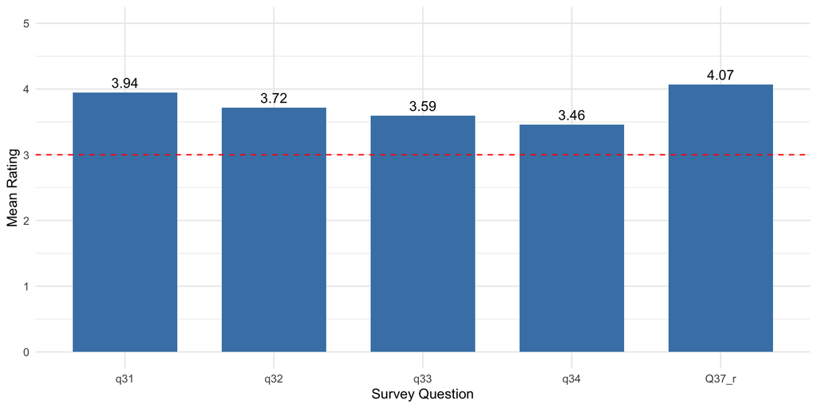

Figure 5: Mean Ratings of Operational Effectiveness

## R6: Findings and Interpretation

The chi-square goodness-of-fit tests for Q9, Q10, Q11, and Q12 showed statistically significant differences from equal response distributions (p < 0.001).

Approximately 77.3% of respondents reported that the frequency of financial statements was about right. Additionally, 97.7% indicated that the statements were easy to understand, and 69.8% of valid respondents believed that their account information was maintained confidentially.

## R6: Findings — Operational Ratings

The one-sample t-tests showed that all five operational effectiveness measures had mean ratings significantly above the neutral midpoint of 3 (p < 0.001).

The overall management and operational rating received the highest mean score (M = 4.066), while the simplicity of loan applications received the lowest mean score (M = 3.461).

Overall, respondents demonstrated positive perceptions of the credit union’s operational effectiveness. However, simplifying loan applications and strengthening confidence in account confidentiality may provide opportunities for further improvement.

## Appendix

### GitHub Repository

[View GitHub Repository](https://github.com/WillySuu/IC11-2-Case31-Data-Analysis)

### Published Presentation

[View Published Presentation](https://willysuu.github.io/IC11-2-Case31-Data-Analysis/)